# STM_example

vicshi94

2023-12-02

### 0. Environments

```r
library(stm)
library(textir)
# 显示中文
library(showtext)
font_files()
showtext_auto(enable = TRUE)
font_add('Songti', 'Songti.ttc')
```

### 1. 读取数据

```r
# load(.Rdata)
# data<-read.csv(file.choose(),sep = ',', quote = '',
#               header = TRUE, fileEncoding = 'utf-8')
data <- read.csv('./corpus_segmented.csv',fileEncoding = 'utf-8')
```

### 2. 提取数据

利用textProcessor算法提取数据,将data文本列和data作为参数 textProcessor暂不支持中文，需要自行预处理 wordLength=c(3,Inf)表示移除短于3，长于inf的词语：中文调为1以免单字被删

```r
processed <- textProcessor(data$Segmented_Content,metadata=data,wordLengths=c(1,Inf))
```

```
## Building corpus...
## Converting to Lower Case...
## Removing punctuation...
## Removing stopwords...
## Removing numbers...
## Stemming...
## Creating Output...
```

### 3. 数据预处理

查看不同阈值删除doc,words,token情况

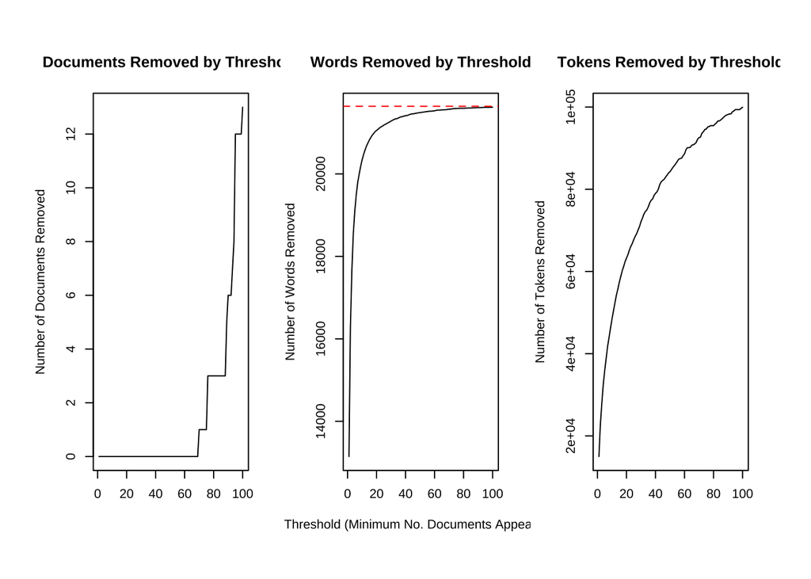

```r
# pdf("output/stm-plot-removed.pdf") # 生成结果文件用的
plotRemoved(processed$documents, lower.thresh=seq(from = 1, to = 100, by =1))
```

```r
# dev.off() # 生成结果文件用的
```

根据结果确定lower.thresh取值 preDocuments默认值为1 在此例中，我们决定将lower.thresh设为10

**建立完整文档-协变量数据**

```r
out <- prepDocuments(
  documents = processed$documents, #包含索引词的计数及文档列表
  vocab = processed$vocab, # 索引词的关联单词
  meta = processed$meta, #包含文档协变量
  lower.thresh = 10)
```

```
## Removing 20334 of 21640 terms (39142 of 74852 tokens) due to frequency
## Your corpus now has 447 documents, 1306 terms and 35710 tokens.
```

### 4. 确定主题数 (非必需)

(如果定好生成几个Topic了，就跳过这一步)

```r
storage <- searchK(
  out$documents, out$vocab,
  K = 5:20, # 生成5～20个topic比较
  prevalence = ~版次, #比如我们想查看版次之间语义区别
  data = out$meta
  )
```

**可视化结果**

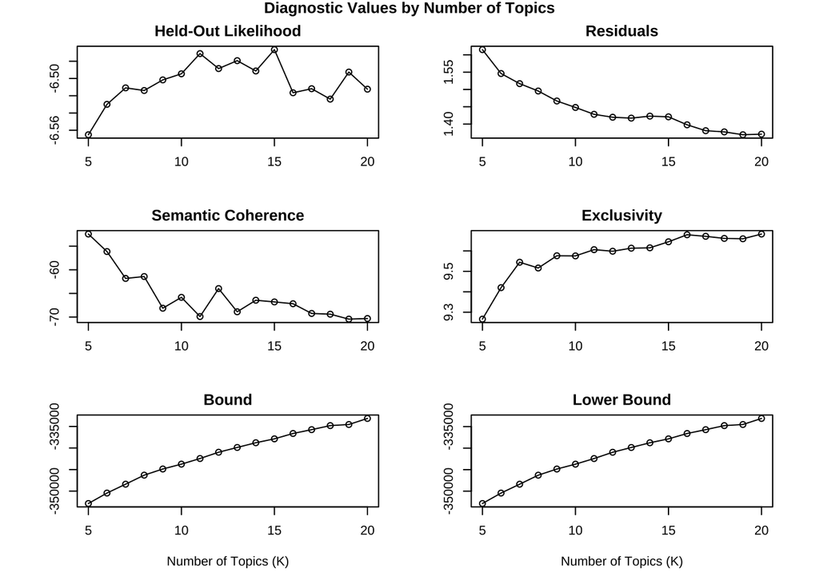

```r
# 自定义 plot.searchK()
plt_searchK<-function(x, ...){
  oldpar <- par(no.readonly=TRUE)
  g <- x$results
  par(mfrow=c(3,2),mar=c(4,4,2,2),oma=c(1,1,1,1))

  plot(g$K,g$heldout,type="p", main="Held-Out Likelihood", xlab="", ylab="")
  lines(g$K,g$heldout,lty=1,col=1)

  plot(g$K,g$residual,type="p", main="Residuals", xlab="", ylab="")
  lines(g$K,g$residual,lty=1,col=1 )

  if(!is.null(g$semcoh)){
    plot(g$K,g$semcoh,type="p", main="Semantic Coherence", xlab="", ylab="")
    lines(g$K,g$semcoh,lty=1,col=1 )
  }

  plot(g$K,g$exclus,type="p", main="Exclusivity", xlab="", ylab="")
  lines(g$K,g$exclus,lty=1,col=1 )

  plot(g$K,g$bound,type="p", main="Bound", xlab="Number of Topics (K)", ylab="")
  lines(g$K,g$bound,lty=1,col=1 )

  plot(g$K,g$lbound,type="p", main="Lower Bound", xlab="Number of Topics (K)", ylab="")
  lines(g$K,g$lbound,lty=1,col=1 )

  title("Diagnostic Values by Number of Topics", outer=TRUE)
  par(oldpar)
}

# 可视化结果
# pdf("stm-plot-ntopics.pdf")
plt_searchK(storage)
```

```r
# dev.off()
```

结果部分主要看Coherence和Exclusivity，需要这两个值都比较高。 严格来说，需要多次模拟，然后决定，但是基本上还是个人评估为主

```r
# 获取具体统计结果
t <- storage$results[[2]] # exclusivity
t <- storage$results[[3]] # coherence
```

这里为了演示，选取Topic = 5

### 5. 指定主题数模型选择

```r
poliblogSelect <- selectModel(
  out$documents, out$vocab, K = 5,
  prevalence = ~版次, #协变量
  max.em.its = 200, data = out$meta,
  runs = 20, #20 models
  seed = 20231202
  )
```

可视化结果，通过语义coherence和exclusivity选择模型(靠右上)

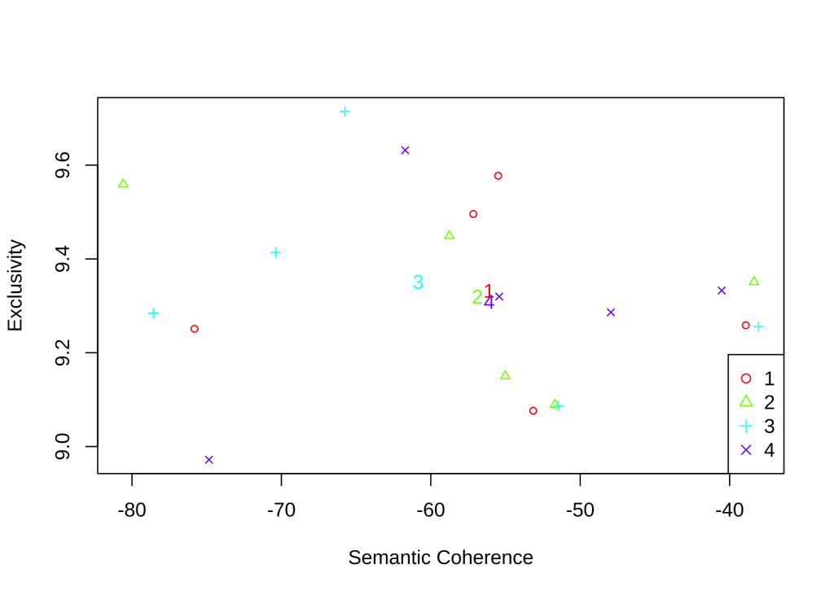

```r
plotModels(poliblogSelect, pch = c(1,2,3,4), legend.position = 'bottomright')
```

选择模型 [1,2,3,4]

```r
selectmodel <- poliblogSelect$runout[[1]]
```

### 6.模型结果

高频词

```r
labelTopicsSel <- labelTopics(selectmodel, c(1:5)) # 输出所有5个主题
# sink("output/labelTopics-selected.txt",append = FALSE, split = TRUE)
print(labelTopicsSel)
```

```
## Topic 1 Top Words:
##       Highest Prob: 群众, 生产, 组织, 政府, 运动, 进行, 工人
##       FREX: 减租, 生产, 万元, 全县, 麦收, 群众, 教育
##       Lift: 共有, 二万, 产量, 亩, 余亩, 反奸, 小麦
##       Score: 生产, 减租, 村, 教育, 工人, 太行, 麦收
## Topic 2 Top Words:
##       Highest Prob: 美国, 延安, 问题, 会议, 要求, 日本, 代表
##       FREX: 罢工, 苏联, 英国, 美国, 外长, 声明, 社会党
##       Lift: 伦敦, 塔斯社, 东京, 内阁, 合众社, 国会, 外长
##       Score: 外长, 英国, 罢工, 苏联, 美国, 巴黎, 内阁
## Topic 3 Top Words:
##       Highest Prob: 人民, 国民党, 内战, 民主, 救济, 反动派, 东北
##       FREX: 堵口, 救济, 黄河, 反动派, 内战, 东北, 人民
##       Lift: 人民日报, 各界, 同胞, 堵口, 政协, 花园口, 保卫和平
##       Score: 国民党, 堵口, 内战, 东北, 黄河, 人民, 反动派
## Topic 4 Top Words:
##       Highest Prob: 国民党, 军, 进攻, 伪军, 解放区, 代表, 小组
##       FREX: 师, 军, 进攻, 永年, 侵占, 日军, 伪军
##       Lift: 官兵, 执行部, 汉口, 济南, 视察, 该城, 驻军
##       Score: 军, 国民党, 伪军, 进犯, 师, 四平, 豫东
## Topic 5 Top Words:
##       Highest Prob: 一个, 们, 把, 要, 去, 还, 这
##       FREX: 们, 佃户, 里, 你, 还, 大家, 把
##       Lift: 像, 却是, 拿, 为什么, 们, 佃户, 写
##       Score: 佃户, 你, 们, 里, 大家, 呢, 还
```

```r
# print(sageLabels(selectmodel)) #另一种输出方式
# sink()
```

列出主题典型文档

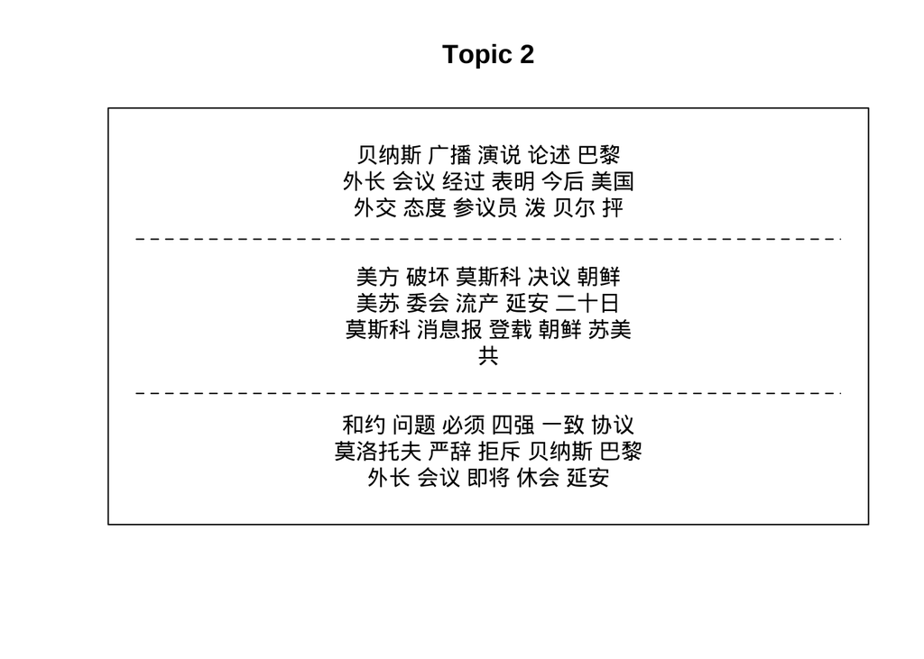

```r
shortdoc <- substr(out$meta$Segmented_Content,1,50) # 前50个字符
thoughts2 <- findThoughts(
  selectmodel, texts = shortdoc, n=3, topics=2 #展示Topic{k}的n篇文档
  )$docs[[1]]
# pdf("output/findThoughts-Topic1.pdf")
plotQuote(thoughts2,width = 30, main = 'Topic 2')
```

```r
# dev.off()
```

列出主题典型文档

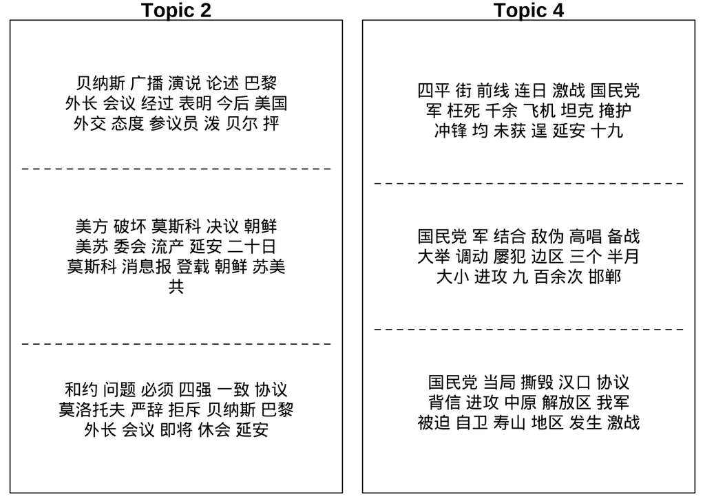

```r
# 多个结果
thoughts4 <- findThoughts(
  selectmodel, texts = shortdoc, n=3, topics=4 #展示Topic{k}的n篇文档
)$docs[[1]]
# pdf("output/findThoughts-Topics.pdf")
par(mfrow=c(1,2),mar=c(.5,.5,1,.5)) # 2x1的表格
plotQuote(thoughts2,width = 30, main = 'Topic 2')
plotQuote(thoughts4,width = 30, main = 'Topic 4')
```

```r
# dev.off()
```

评估协变量对所有主题的影响

```r
out$meta$版次 <- as.factor(out$meta$版次)
prep <- estimateEffect(
  # 对所有主题的影响
  1:5 ~ 版次,
  selectmodel, meta=out$meta,
  uncertainty = 'Global' # OR "Local", "None"
  # 考虑全局不确定性，选择None会加速计算时间，获得更窄的置信区间
)

summary(prep, topics=1)
```

```
##
## Call:
## estimateEffect(formula = 1:5 ~ 版次, stmobj = selectmodel,
##     metadata = out$meta, uncertainty = "Global")
##
##
## Topic 1:
##
## Coefficients:
##             Estimate Std. Error t value Pr(>|t|)
## (Intercept)  0.06234    0.01943   3.208  0.00144 **
## 版次第2版    0.45805    0.02938  15.592  < 2e-16 ***
## 版次第3版   -0.03836    0.08779  -0.437  0.66239
## 版次第4版   -0.06178    0.12006  -0.515  0.60710
## ---
## Signif. codes:  0 '***' 0.001 '**' 0.01 '*' 0.05 '.' 0.1 ' ' 1
```

```r
summary(prep, topics=2)
```

```
##
## Call:
## estimateEffect(formula = 1:5 ~ 版次, stmobj = selectmodel,
##     metadata = out$meta, uncertainty = "Global")
##
##
## Topic 2:
##
## Coefficients:
##             Estimate Std. Error t value Pr(>|t|)
## (Intercept)  0.40640    0.02179  18.648  < 2e-16 ***
## 版次第2版   -0.36463    0.02936 -12.419  < 2e-16 ***
## 版次第3版    0.19613    0.10411   1.884  0.06023 .
## 版次第4版   -0.37619    0.13420  -2.803  0.00528 **
## ---
## Signif. codes:  0 '***' 0.001 '**' 0.01 '*' 0.05 '.' 0.1 ' ' 1
```

### 7.其他可视化结果

主题占比条形图

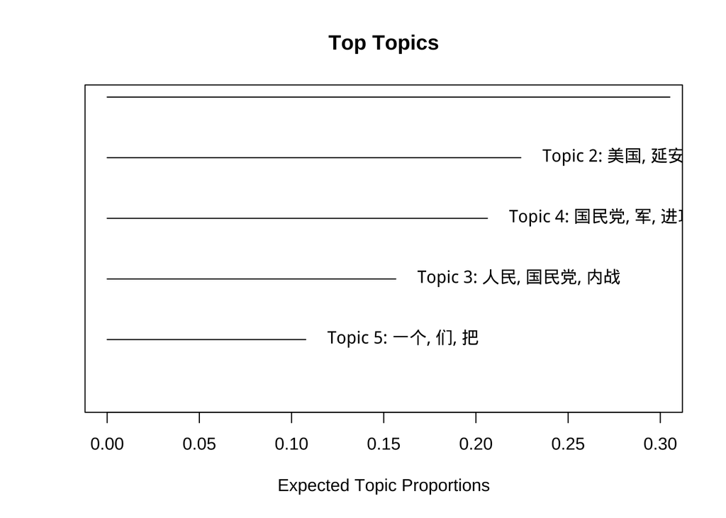

```r
# pdf("top-topic.pdf)
plot(selectmodel,type = 'summary', xlim = c(0,.3))
```

```r
# dev.off()
```

主题关系对比图

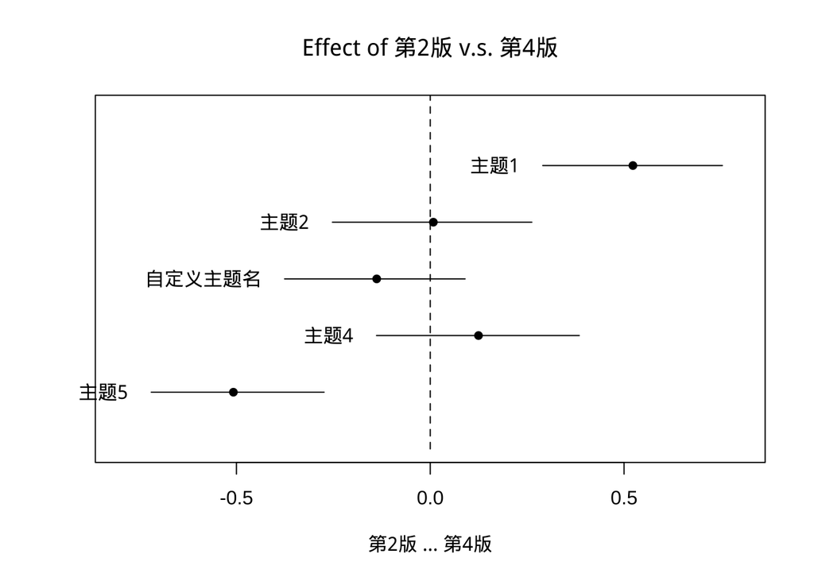

```r
# pdf("stm-plot-topical-prevalence-contrast.pdf")
plot(
  prep, covariate = '版次', topics = c(1,2,3,4,5),
  model = selectmodel, method = 'difference',
  cov.value1 = '第2版', cov.value2 = '第4版',
  xlab = '第2版 ... 第4版',
  main = 'Effect of 第2版 v.s. 第4版',
  xlim = c(-.8,.8), # 控制x轴范围
  labeltype = 'custom',
  custom.labels = c("主题1", '主题2', "自定义主题名","主题4", '主题5')
)
```

```r
#dev.off()
```

主题关系网络图

```r
# require igraph
mod.out.corr <- topicCorr(selectmodel)
# pdf("stm-plot-topic-correlations.pdf")
plot(mod.out.corr)
# dev.off()
```

[output not shown]